# Data cleaning, descriptives, reliability, histograms, correlations

# Scatterplots

Overall scores:

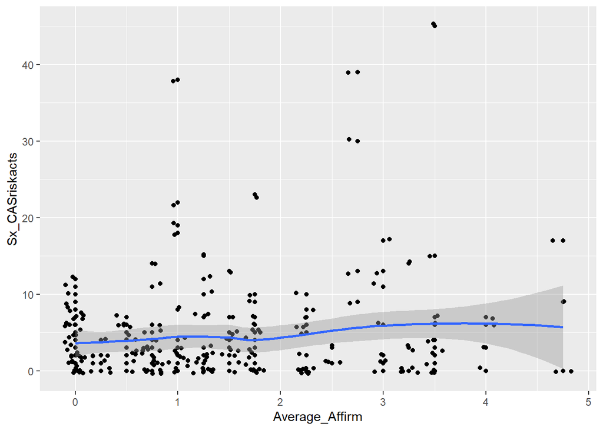

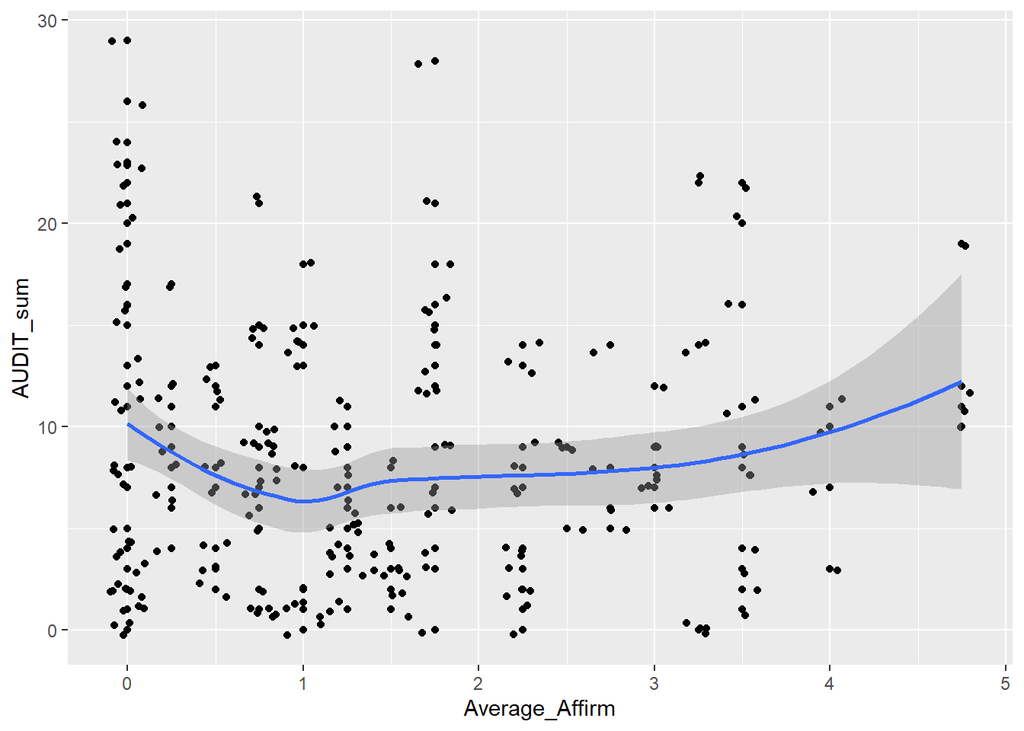

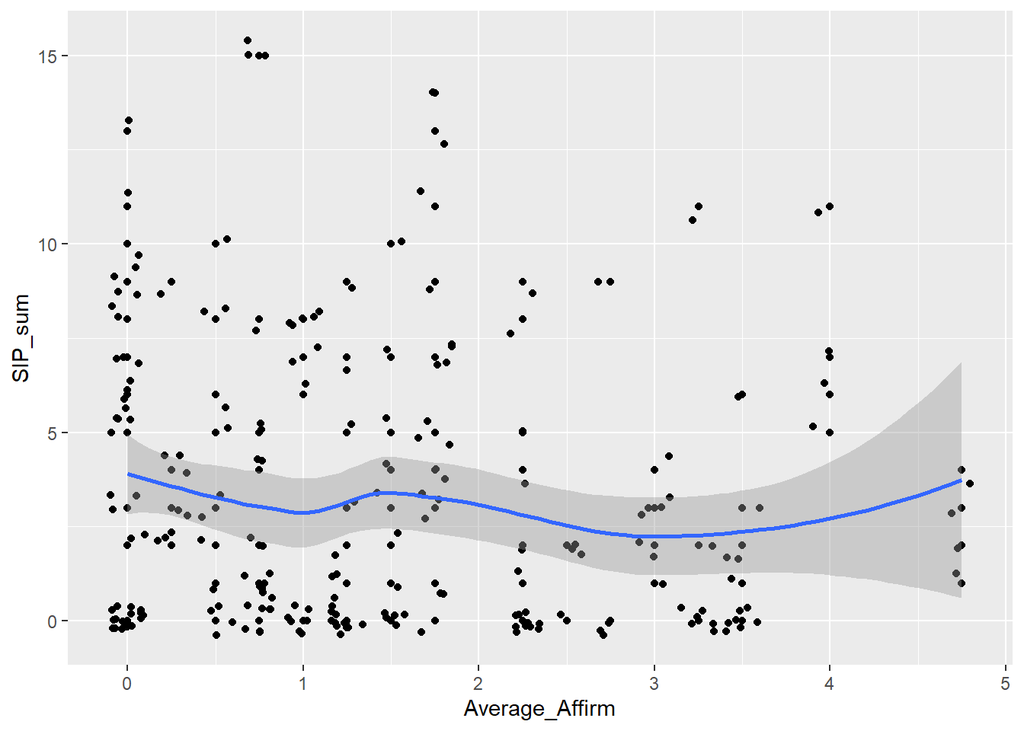

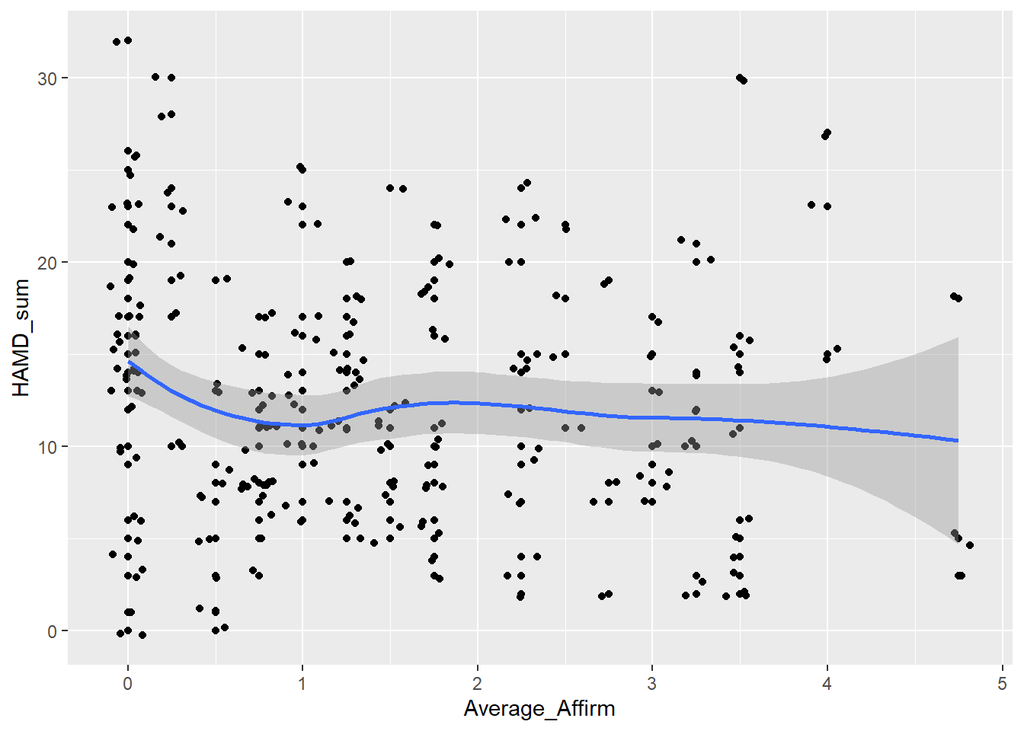

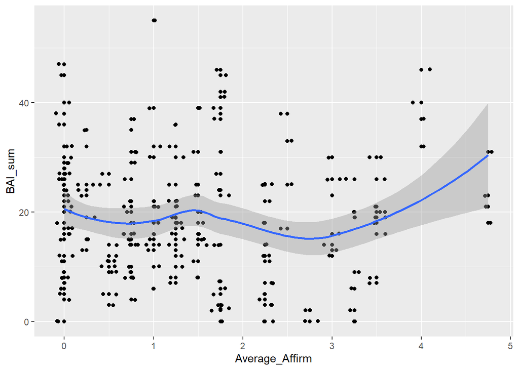

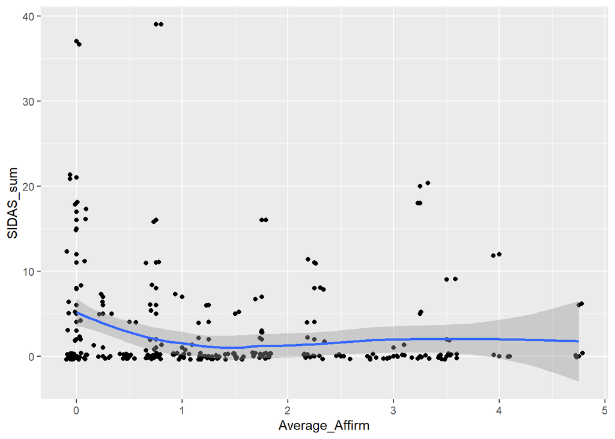

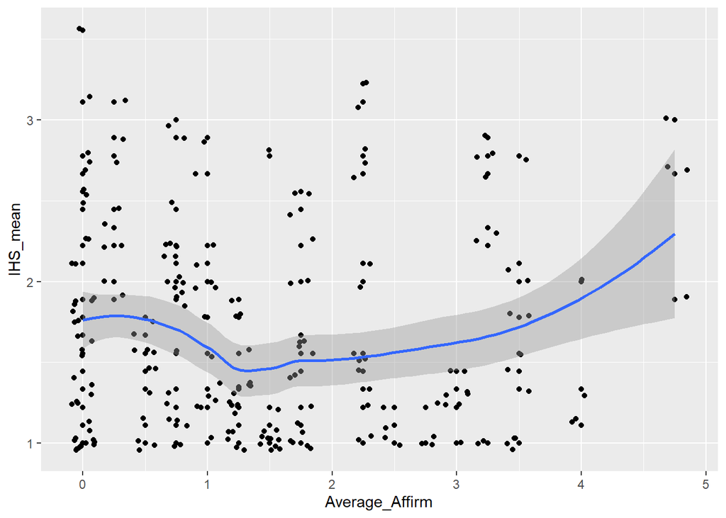

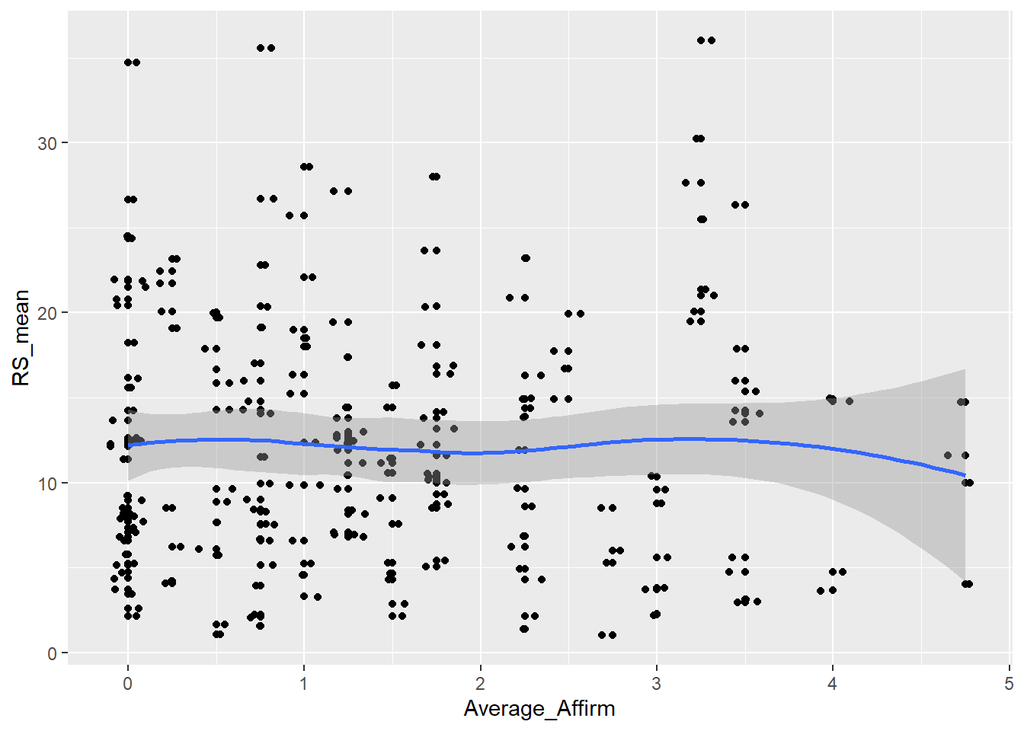

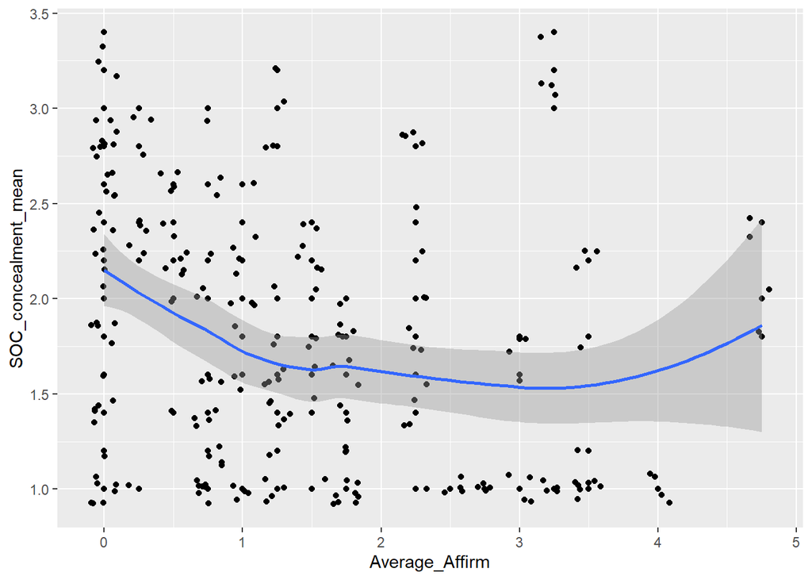

```r
#apps_outcome |>
#  ggplot(aes(x = Average_Affirm, y = HAMD_sum)) +
#  geom_point() +
#  geom_jitter() +
#  stat_smooth(method = "loess")

scatter <- function(data, outcome_vars) {
  plots <- map(outcome_vars, function(var) {
    var_sym <- sym(var)
    data |>
      ggplot(aes(x = Average_Affirm, y = !!var_sym)) +
      geom_point() +
      geom_jitter() +
      stat_smooth(method = "loess")
  })

  return(plots)
}

scatter(apps_outcome, outcome_vars)
```

Just post-treatment scores to make this clearer. Note that we wrote over the function above.

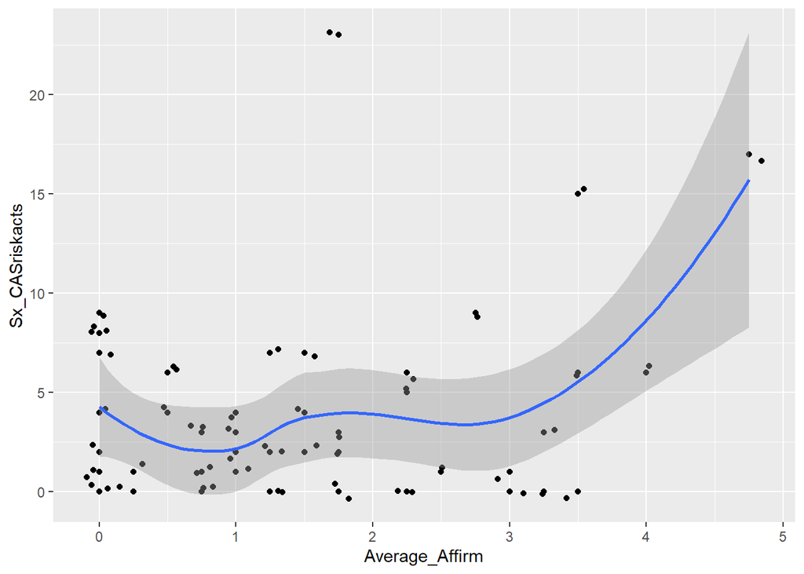

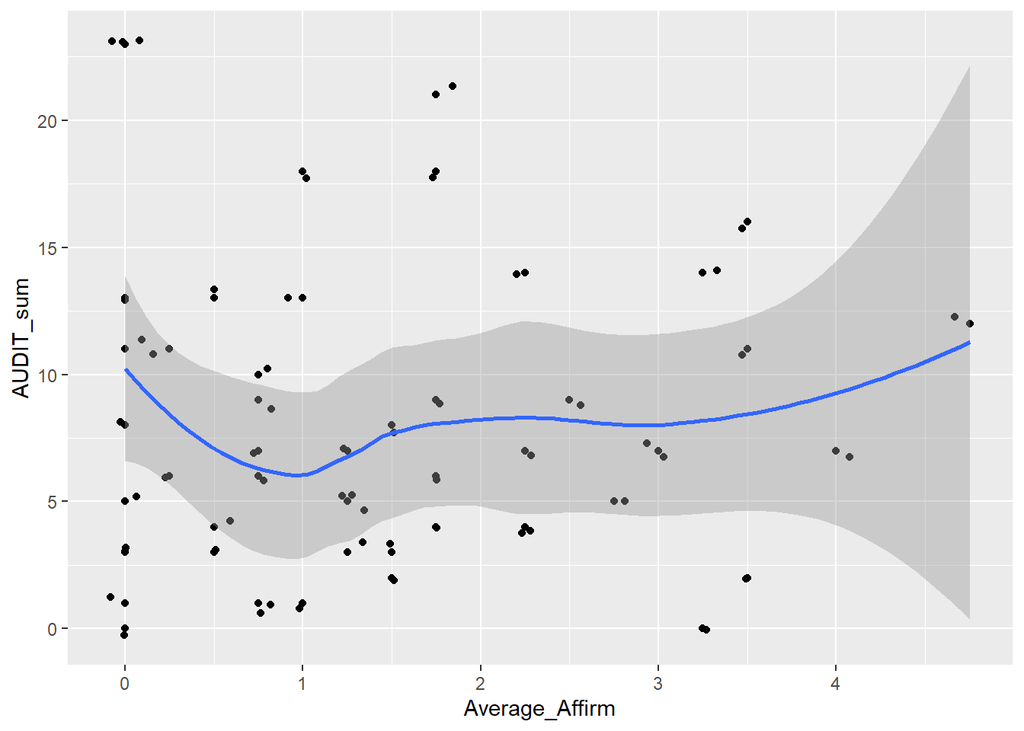

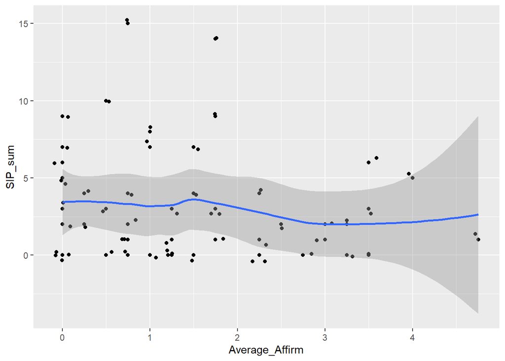

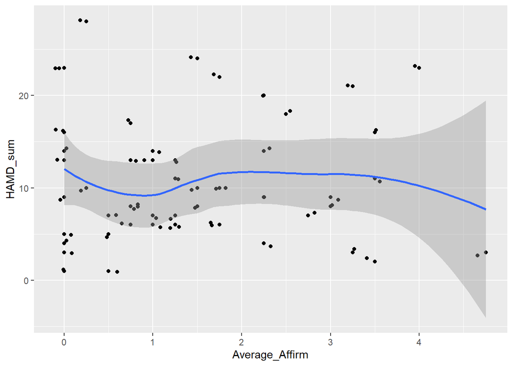

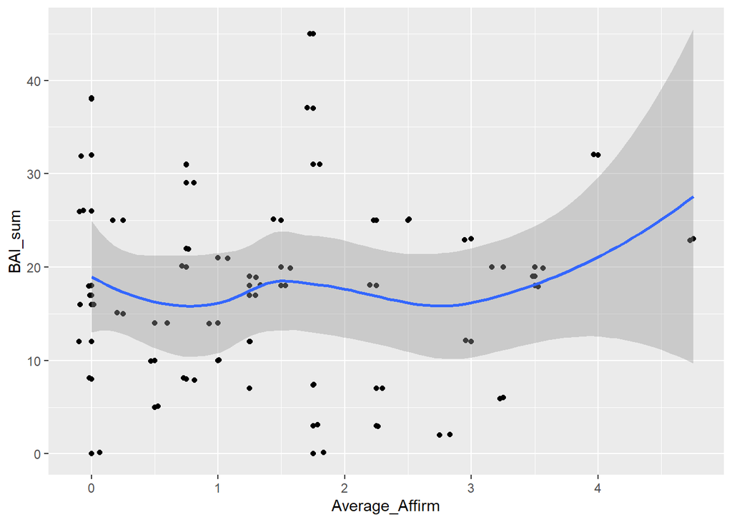

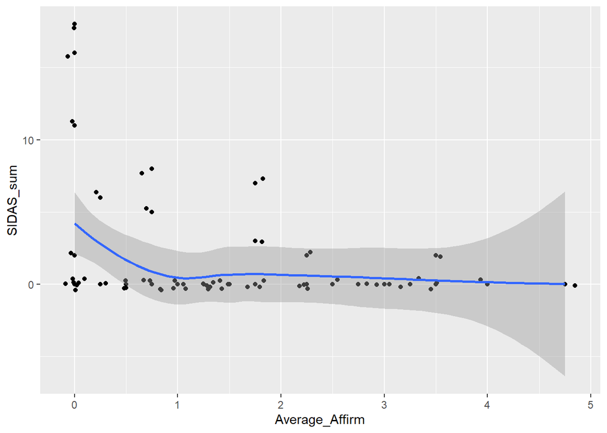

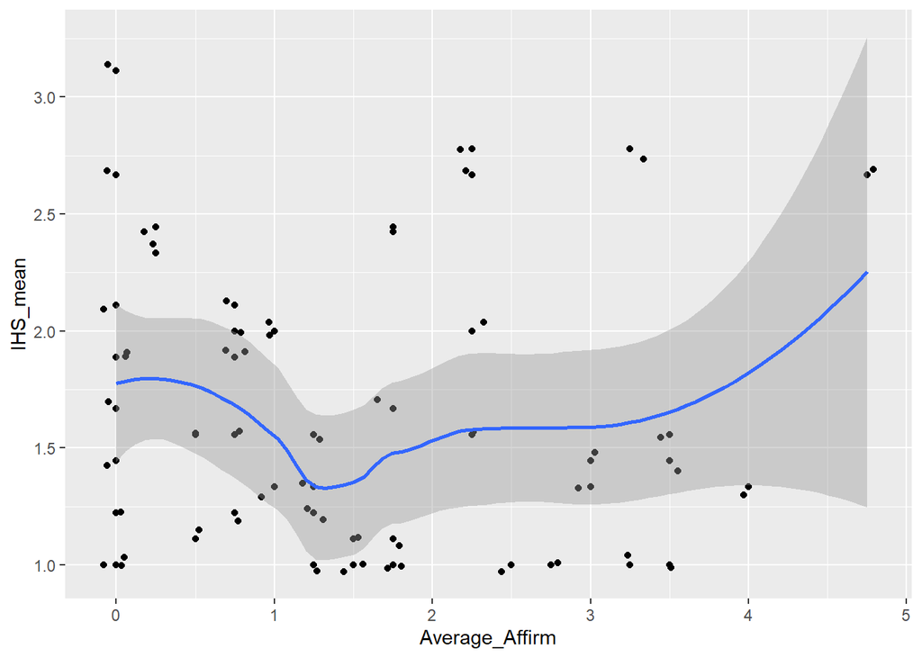

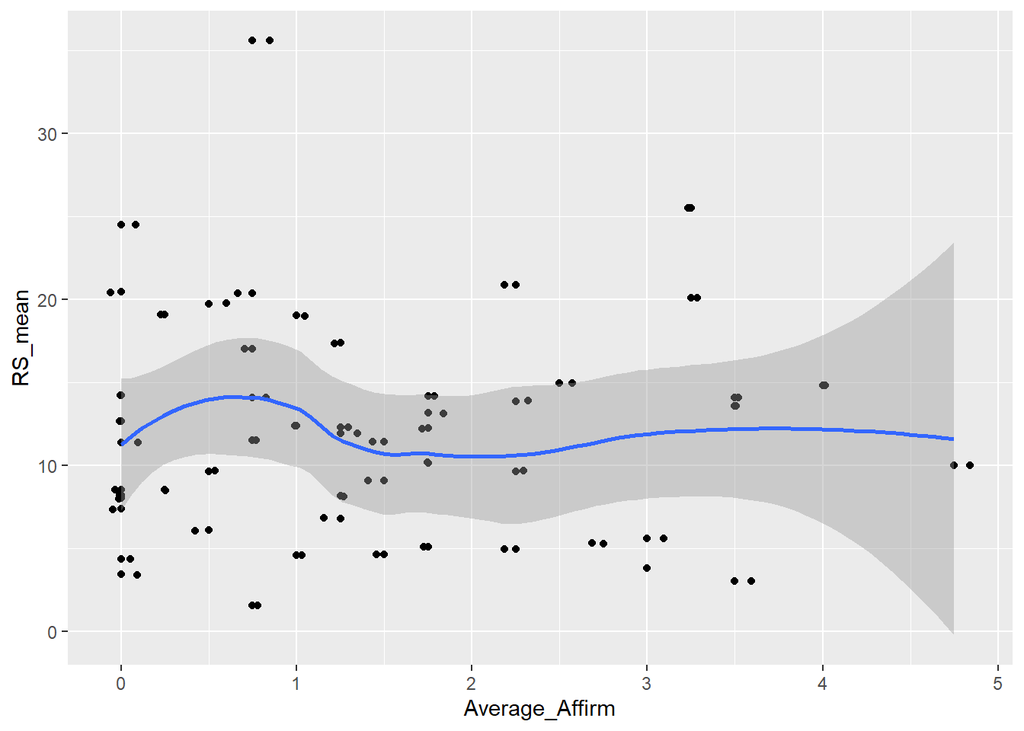

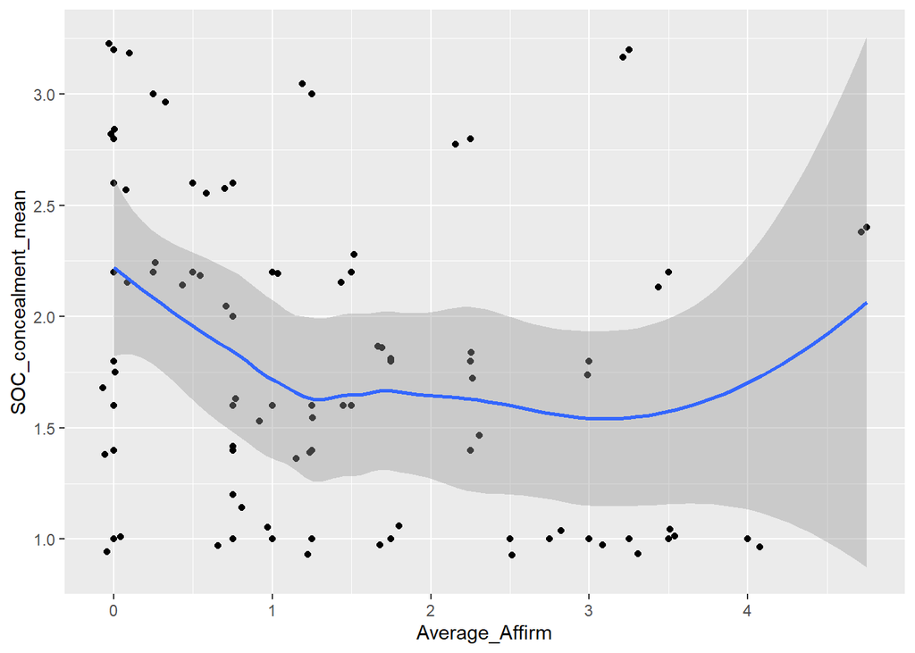

```r
scatter <- function(data, outcome_vars) {
  plots <- map(outcome_vars, function(var) {
    var_sym <- sym(var)
    data |>
      filter(Assessment == 1) |>
      ggplot(aes(x = Average_Affirm, y = !!var_sym)) +
      geom_point() +
      geom_jitter() +
      stat_smooth(method = "loess")
  })

  return(plots)
}

scatter(apps_outcome, outcome_vars)
```

Inspection of the bivariate scatterplot shows that there are a couple of points at the far range of the LADI that might be influencing the bivariate relationship. Let’s identify what those scores are:

```r
apps_outcome |>
  frq(Average_Affirm)
```

```
Average of early and mid-sessions LGBTQ-APPS Score (Average_Affirm) <numeric>
# total N=228 valid N=228 mean=1.38 sd=1.20

Value |  N | Raw % | Valid % | Cum. %
-------------------------------------
 0.00 | 44 | 19.30 |   19.30 |  19.30
 0.25 | 12 |  5.26 |    5.26 |  24.56
 0.50 | 16 |  7.02 |    7.02 |  31.58
 0.75 | 24 | 10.53 |   10.53 |  42.11
 1.00 | 16 |  7.02 |    7.02 |  49.12
 1.25 | 20 |  8.77 |    8.77 |  57.89
 1.50 | 12 |  5.26 |    5.26 |  63.16
 1.75 | 24 | 10.53 |   10.53 |  73.68
 2.25 | 16 |  7.02 |    7.02 |  80.70
 2.50 |  4 |  1.75 |    1.75 |  82.46
 2.75 |  4 |  1.75 |    1.75 |  84.21
 3.00 |  8 |  3.51 |    3.51 |  87.72
 3.25 |  8 |  3.51 |    3.51 |  91.23
 3.50 | 12 |  5.26 |    5.26 |  96.49
 4.00 |  4 |  1.75 |    1.75 |  98.25
 4.75 |  4 |  1.75 |    1.75 | 100.00
 <NA> |  0 |  0.00 |    <NA> |   <NA>
```

Ok we see here that those are likely the one participant whose therapist scored scored a 4.75 on the LADI. Let’s exclude those to see how sensitive the plots are to those two points. Note that we wrote over the function above to make this easier.

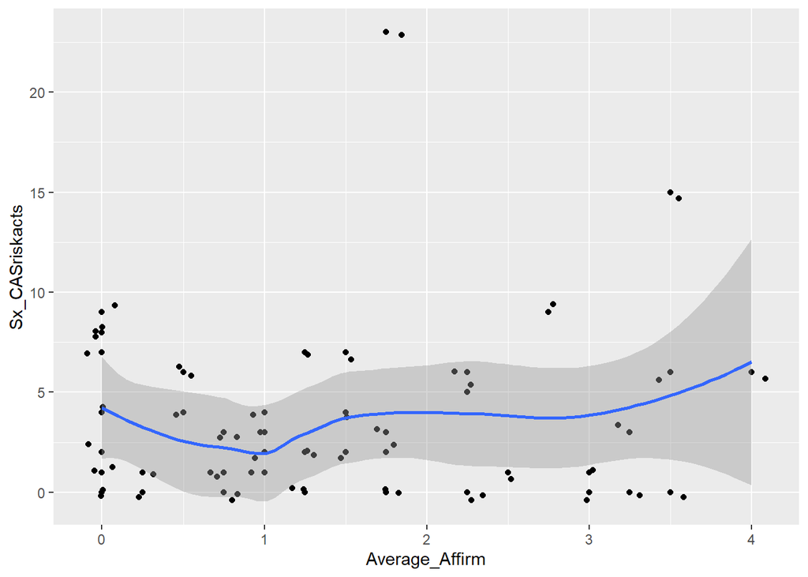

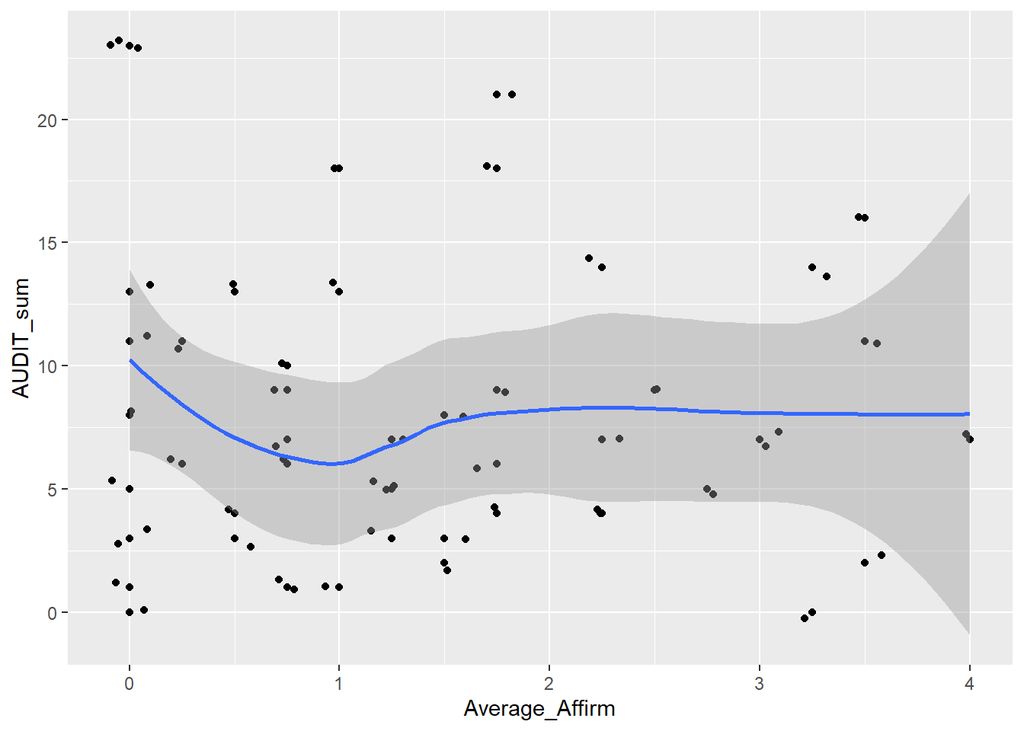

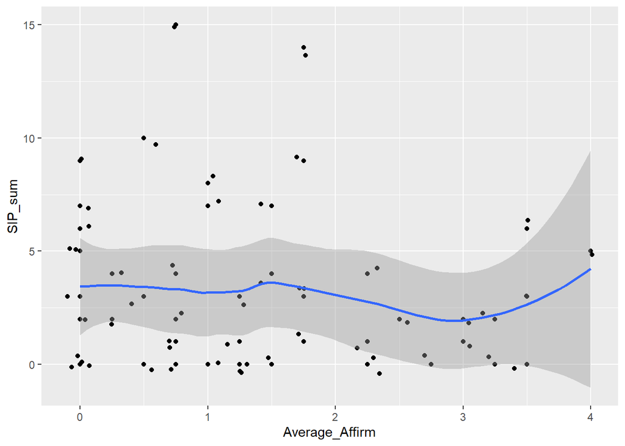

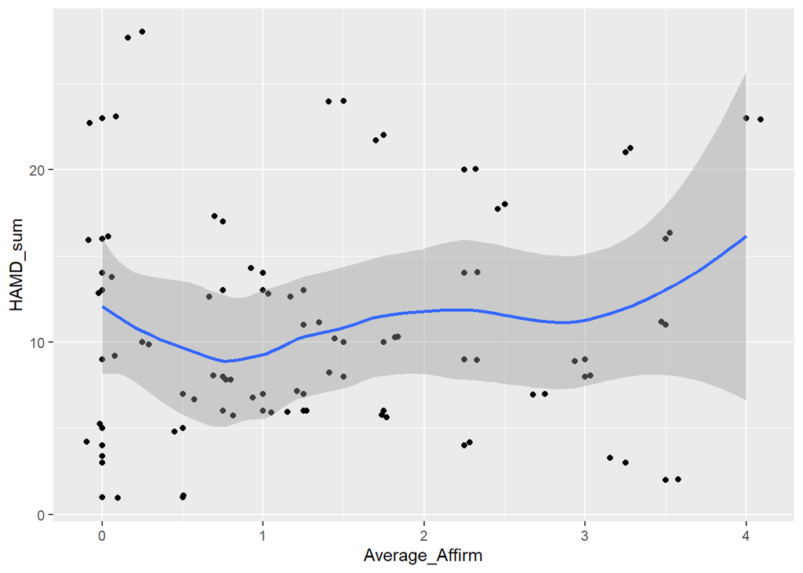

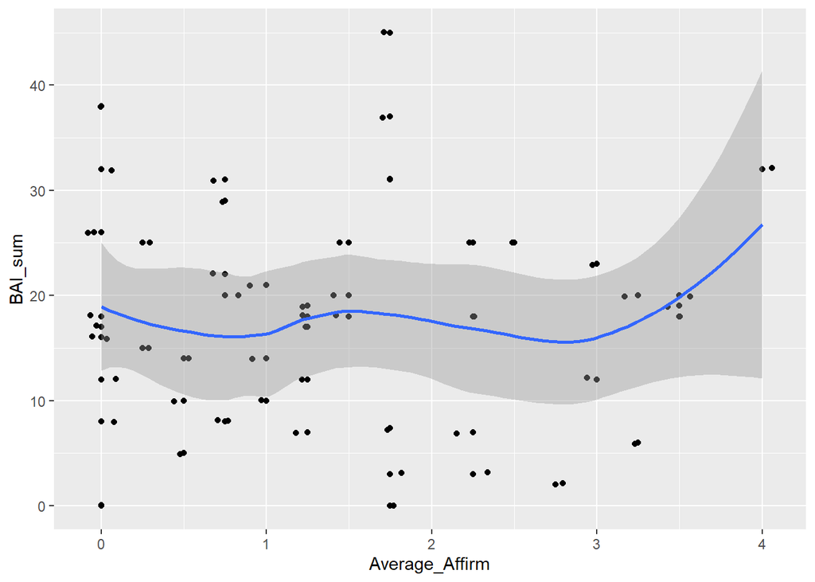

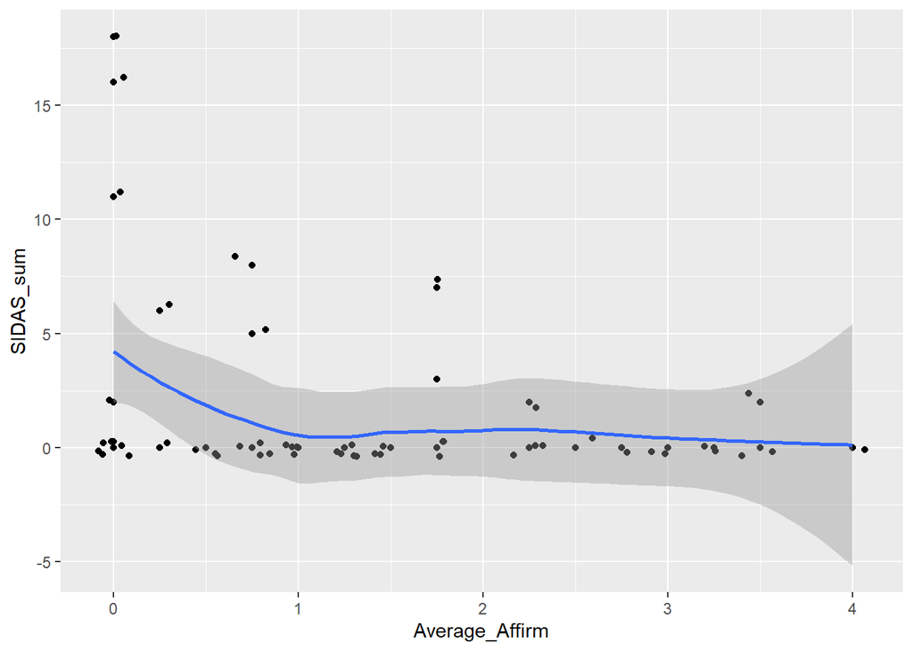

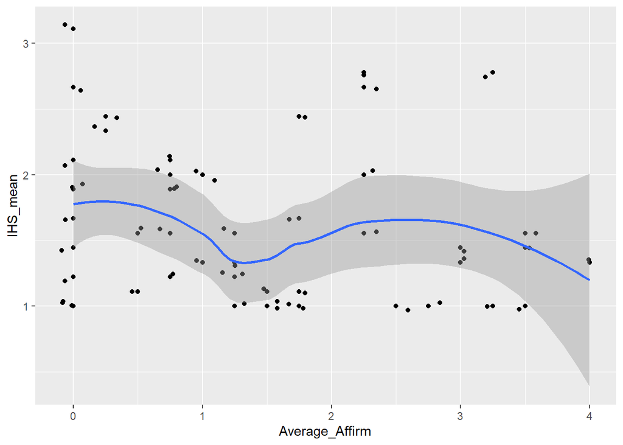

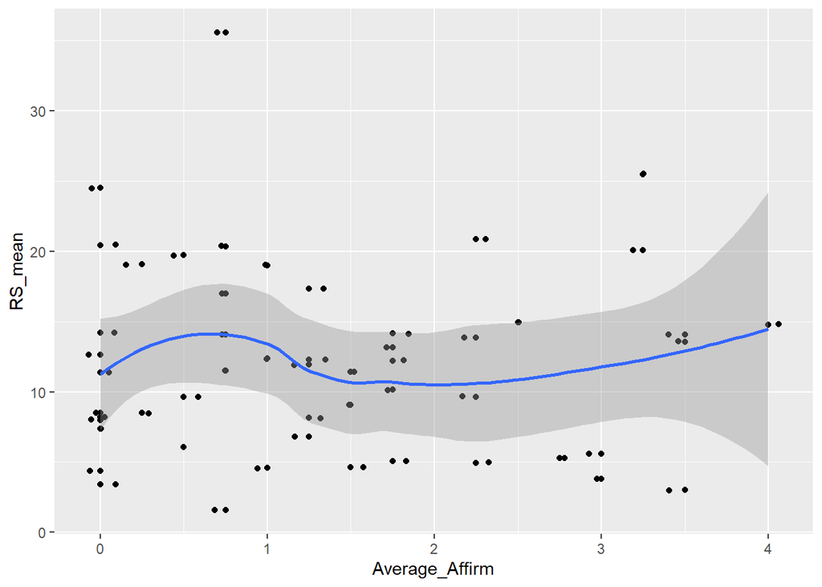

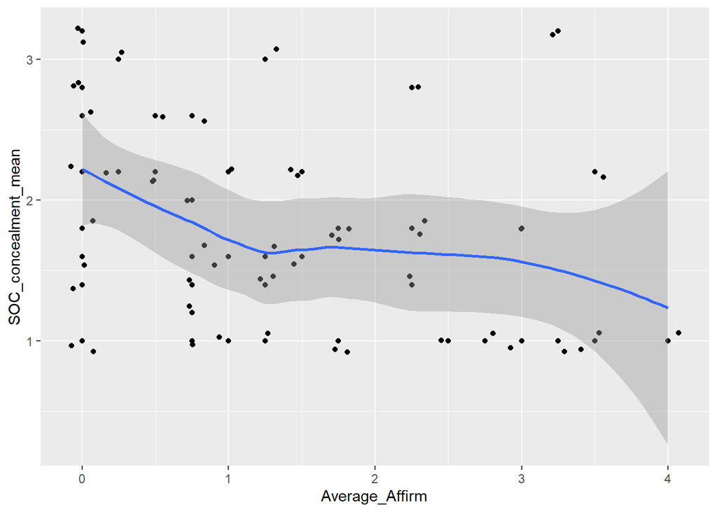

```r
scatter <- function(data, outcome_vars) {
  plots <- map(outcome_vars, function(var) {
    var_sym <- sym(var)
    data |>
      filter(Assessment == 1) |>
      filter(Average_Affirm != 4.75) |>
      ggplot(aes(x = Average_Affirm, y = !!var_sym)) +
      geom_point() +
      geom_jitter() +
      stat_smooth(method = "loess")
  })

  return(plots)
}

scatter(apps_outcome, outcome_vars)
```

By and large the scatterplots are similar with and without the excluded folks. However, the HAMD, IHS, and SOC are all measures that seem to change. Here is the before and after for each to showcase this.

For HAMD:

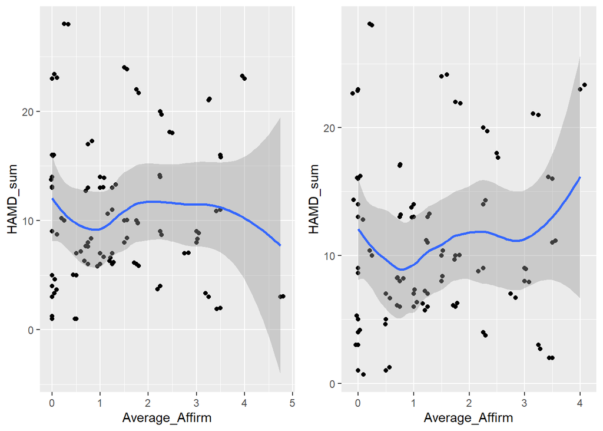

```r
hamd.1 <- apps_outcome |>
      filter(Assessment == 1) |>
      ggplot(aes(x = Average_Affirm, y = HAMD_sum)) +
      geom_point() +
      geom_jitter() +
      stat_smooth(method = "loess")

hamd.2 <- apps_outcome |>
      filter(Assessment == 1) |>
      filter(Average_Affirm != 4.75) |>
      ggplot(aes(x = Average_Affirm, y = HAMD_sum)) +
      geom_point() +
      geom_jitter() +
      stat_smooth(method = "loess")

grid.arrange(hamd.1, hamd.2, ncol = 2)
```

For IHS:

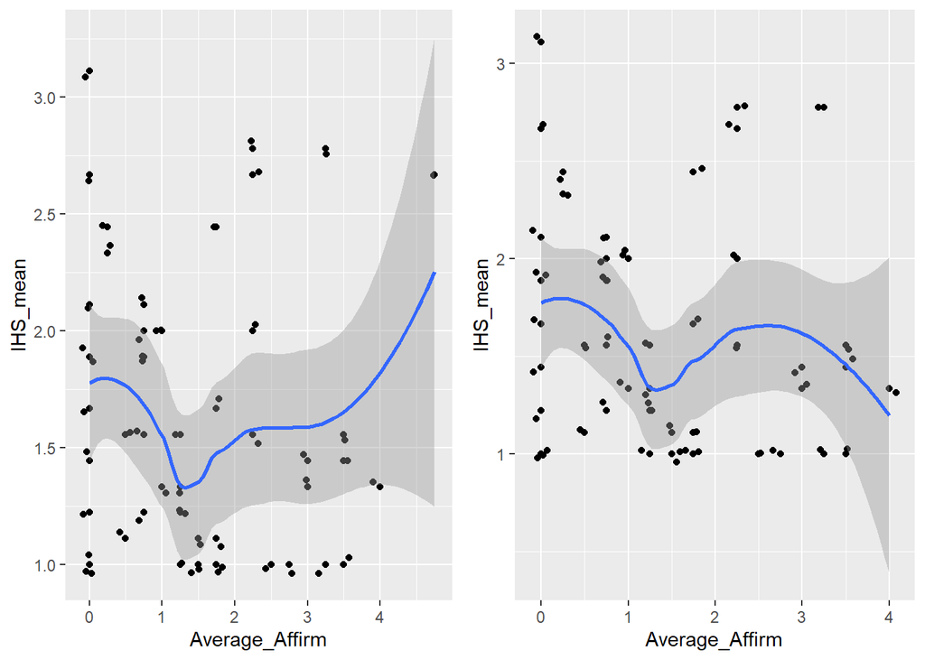

```r
ihs.1 <- apps_outcome |>
      filter(Assessment == 1) |>
      ggplot(aes(x = Average_Affirm, y = IHS_mean)) +
      geom_point() +
      geom_jitter() +
      stat_smooth(method = "loess")

ihs.2 <- apps_outcome |>
      filter(Assessment == 1) |>
      filter(Average_Affirm != 4.75) |>
      ggplot(aes(x = Average_Affirm, y = IHS_mean)) +
      geom_point() +
      geom_jitter() +
      stat_smooth(method = "loess")

grid.arrange(ihs.1, ihs.2, ncol = 2)
```

For SOC:

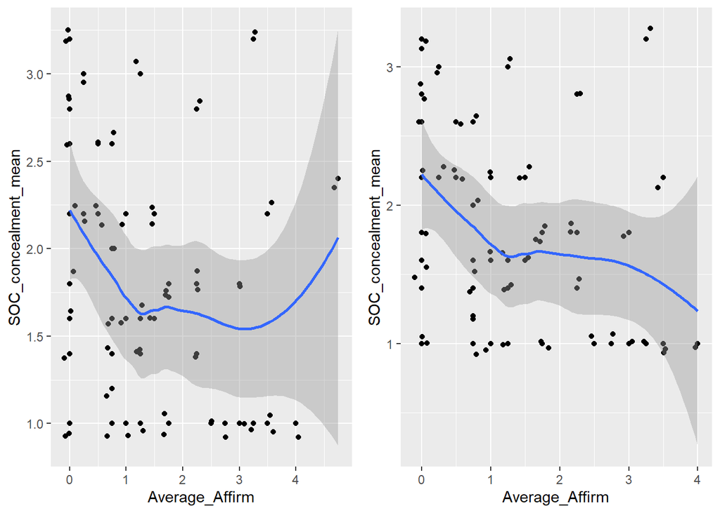

```r
soc.1 <- apps_outcome |>
      filter(Assessment == 1) |>
      ggplot(aes(x = Average_Affirm, y = SOC_concealment_mean)) +
      geom_point() +
      geom_jitter() +
      stat_smooth(method = "loess")

soc.2 <- apps_outcome |>
      filter(Assessment == 1) |>
      filter(Average_Affirm != 4.75) |>
      ggplot(aes(x = Average_Affirm, y = SOC_concealment_mean)) +
      geom_point() +
      geom_jitter() +
      stat_smooth(method = "loess")

grid.arrange(soc.1, soc.2, ncol = 2)
```

# Correlations

We’ll pull a correlation matrix for variables across all time points.

```r
corr_results <- correlation(data = apps_outcome,
            select = c("Sx_CASriskacts", "Sx_totalacts_sum", "AUDIT_sum", "SIP_sum", "HAMD_sum", "BAI_sum", "SIDAS_sum", "IHS_mean", "RS_mean", "SOC_concealment_mean", "Average_Affirm", "WAI_avg")) |>
  summary(redundant = T)
corr_results
```

```
# Correlation Matrix (pearson-method)

Parameter            | Sx_CASriskacts | Sx_totalacts_sum | AUDIT_sum | SIP_sum
------------------------------------------------------------------------------
Sx_CASriskacts       |                |          0.60*** |     0.22* |    0.20
Sx_totalacts_sum     |        0.60*** |                  |      0.19 |    0.18
AUDIT_sum            |          0.22* |             0.19 |           | 0.64***
SIP_sum              |           0.20 |             0.18 |   0.64*** |
HAMD_sum             |           0.04 |             0.08 |      0.22 |  0.26**
BAI_sum              |          -0.02 |             0.02 |     0.24* |  0.29**
SIDAS_sum            |          -0.06 |             0.01 |      0.16 |    0.16
IHS_mean             |           0.06 |             0.10 |    0.27** |    0.21
RS_mean              |           0.04 |             0.16 |      0.18 |  0.27**
SOC_concealment_mean |          -0.10 |             0.04 |     -0.07 |   -0.05
Average_Affirm       |           0.13 |             0.08 |     -0.02 |   -0.12
WAI_avg              |          -0.01 |             0.01 |      0.08 |    0.12

Parameter            | HAMD_sum | BAI_sum | SIDAS_sum | IHS_mean | RS_mean
--------------------------------------------------------------------------
Sx_CASriskacts       |     0.04 |   -0.02 |     -0.06 |     0.06 |    0.04
Sx_totalacts_sum     |     0.08 |    0.02 |      0.01 |     0.10 |    0.16
AUDIT_sum            |     0.22 |   0.24* |      0.16 |   0.27** |    0.18
SIP_sum              |   0.26** |  0.29** |      0.16 |     0.21 |  0.27**
HAMD_sum             |          | 0.37*** |   0.29*** |    0.24* |  0.26**
BAI_sum              |  0.37*** |         |      0.15 |     0.10 |   0.23*
SIDAS_sum            |  0.29*** |    0.15 |           |     0.13 |    0.14
IHS_mean             |    0.24* |    0.10 |      0.13 |          | 0.34***
RS_mean              |   0.26** |   0.23* |      0.14 |  0.34*** |
SOC_concealment_mean |     0.02 |   -0.06 |      0.09 |  0.35*** |    0.18
Average_Affirm       |    -0.12 |   -0.02 |     -0.15 |    -0.02 |   -0.01
WAI_avg              |    -0.13 |   -0.09 |     -0.05 |    -0.14 |    0.09

Parameter            | SOC_concealment_mean | Average_Affirm | WAI_avg
----------------------------------------------------------------------
Sx_CASriskacts       |                -0.10 |           0.13 |   -0.01
Sx_totalacts_sum     |                 0.04 |           0.08 |    0.01
AUDIT_sum            |                -0.07 |          -0.02 |    0.08
SIP_sum              |                -0.05 |          -0.12 |    0.12
HAMD_sum             |                 0.02 |          -0.12 |   -0.13
BAI_sum              |                -0.06 |          -0.02 |   -0.09
SIDAS_sum            |                 0.09 |          -0.15 |   -0.05
IHS_mean             |              0.35*** |          -0.02 |   -0.14
RS_mean              |                 0.18 |          -0.01 |    0.09
SOC_concealment_mean |                      |        -0.27** |  -0.23*
Average_Affirm       |              -0.27** |                |    0.15
WAI_avg              |               -0.23* |           0.15 |

p-value adjustment method: Holm (1979)
```

Specifically for the WAI & LADI:

```r
# since only 1 score for alliance and LADI, reduce dataset to n=57
ladi <- apps_outcome |>
  group_by(ParticipantID) |>
  slice_head() |>
  ungroup() |>
  select(ParticipantID, contains("affirm"), contains("WAI"))

cor.test(ladi$WAI_early, ladi$Early_Affirm)
```

```
    Pearson's product-moment correlation

data:  ladi$WAI_early and ladi$Early_Affirm
t = 0.82886, df = 54, p-value = 0.4108
alternative hypothesis: true correlation is not equal to 0
95 percent confidence interval:
 -0.1553967  0.3642502
sample estimates:
      cor
0.1120828
```

```r
cor.test(ladi$WAI_mid, ladi$Mid_Affirm)
```

```
    Pearson's product-moment correlation

data:  ladi$WAI_mid and ladi$Mid_Affirm
t = 1.2238, df = 55, p-value = 0.2262
alternative hypothesis: true correlation is not equal to 0
95 percent confidence interval:
 -0.1020791  0.4061557
sample estimates:
      cor
0.1628194
```

```r
cor.test(ladi$WAI_avg, ladi$Average_Affirm)
```

```
    Pearson's product-moment correlation

data:  ladi$WAI_avg and ladi$Average_Affirm
t = 1.1246, df = 55, p-value = 0.2656
alternative hypothesis: true correlation is not equal to 0
95 percent confidence interval:
 -0.1151378  0.3950619
sample estimates:
      cor
0.1499278
```

```r
# clean up environment
rm(ladi)
```

# ICCs

We’ll calculate ICCs from a random intercepts MLM. First, we’ll evaluate nesting of timepoints within participants.

```r
# function to calculate ICCs for all outcomes
icc_pt <- apps_outcome %>%
  select(ParticipantID, Assessment_c, Sx_CASriskacts, Sx_totalacts_sum, AUDIT_sum, SIP_sum, HAMD_sum, BAI_sum, SIDAS_sum, IHS_mean, RS_mean, SOC_concealment_mean, LGBIS_identaffirm) %>%
  pivot_longer(c(Sx_CASriskacts, Sx_totalacts_sum, AUDIT_sum, SIP_sum, HAMD_sum, BAI_sum, SIDAS_sum, IHS_mean, RS_mean, SOC_concealment_mean, LGBIS_identaffirm),
               names_to = "variable",
               values_to = "outcome") %>%
  mutate(variable = as.factor(variable)) %>%
  group_by(variable) %>%
  group_split() %>%
  map_dfr(.f = function(df) {
    lmer(outcome ~ 1 + (1 | ParticipantID), REML = T, data = df) %>%
      broom.mixed::tidy(effects = "ran_pars", ddf.method = "Kenward-Roger", scales = "vcov") %>%
      add_column(variable = unique(df$variable), .before = 1) %>%
      group_by(variable) %>%
      summarize(pt_var = first(estimate),
                total_var = sum(estimate),
                icc = pt_var/total_var)
  })
icc_pt %>% select(variable, icc) %>% mutate_if(is.numeric, round, digits = 3)
```

```
# A tibble: 11 × 2
   variable               icc
   <fct>                <dbl>
 1 AUDIT_sum            0.721
 2 BAI_sum              0.506
 3 HAMD_sum             0.236
 4 IHS_mean             0.677
 5 LGBIS_identaffirm    0.776
 6 RS_mean              0.624
 7 SIDAS_sum            0.328
 8 SIP_sum              0.63
 9 SOC_concealment_mean 0.872
10 Sx_CASriskacts       0.305
11 Sx_totalacts_sum     0.232
```

Second, we’ll consider nesting of participants within therapists.

```r
icc_ther <- apps_outcome |>
  select(ParticipantID, TherapistID, Sx_CASriskacts, Sx_totalacts_sum, AUDIT_sum, SIP_sum, HAMD_sum, BAI_sum, SIDAS_sum, IHS_mean, RS_mean, SOC_concealment_mean, LGBIS_identaffirm) |>
  pivot_longer(c(Sx_CASriskacts, Sx_totalacts_sum, AUDIT_sum, SIP_sum, HAMD_sum, BAI_sum, SIDAS_sum, IHS_mean, RS_mean, SOC_concealment_mean, LGBIS_identaffirm),
               names_to = "variable",
               values_to = "outcome") |>
  mutate(variable = as.factor(variable)) |>
  group_by(variable) |>
  group_split() |>
  map_dfr(.f = function(df) {
    lmer(outcome ~ 1 + (1 | ParticipantID) + (1 | TherapistID), REML = T, data = df) |>
      broom.mixed::tidy(effects = "ran_pars", ddf.method = "Kenward-Roger", scales = "vcov") |>
      add_column(variable = unique(df$variable), .before = 1) |>
      group_by(variable) |>
      summarize(pt_var = first(estimate),
                ther_var = nth(estimate, 2),
                total_var = sum(estimate),
                icc_ther = ther_var / total_var,
                icc_pt = (pt_var + ther_var) / total_var)
  })
```

```
boundary (singular) fit: see help('isSingular')
boundary (singular) fit: see help('isSingular')
boundary (singular) fit: see help('isSingular')
boundary (singular) fit: see help('isSingular')
boundary (singular) fit: see help('isSingular')
boundary (singular) fit: see help('isSingular')
boundary (singular) fit: see help('isSingular')
```

```r
icc_ther |> select(variable, icc_pt, icc_ther) |> mutate_if(is.numeric, round, digits = 3)
```

```
# A tibble: 11 × 3
   variable             icc_pt icc_ther
   <fct>                 <dbl>    <dbl>
 1 AUDIT_sum             0.721    0
 2 BAI_sum               0.507    0.014
 3 HAMD_sum              0.236    0
 4 IHS_mean              0.677    0
 5 LGBIS_identaffirm     0.776    0
 6 RS_mean               0.624    0
 7 SIDAS_sum             0.328    0
 8 SIP_sum               0.63     0.02
 9 SOC_concealment_mean  0.872    0
10 Sx_CASriskacts        0.323    0.141
11 Sx_totalacts_sum      0.232    0.021
```

Of note, there were 24 unique therapists and many only had 1 participant in the sample.

```r
apps_outcome |>
  group_by(TherapistID) |>
  summarize(n_distinct(ParticipantID)) |>
  rename(number_pts = "n_distinct(ParticipantID)")
```

```
# A tibble: 24 × 2
   TherapistID number_pts
   <dbl+lbl>        <int>
 1  1 [AG]              1
 2  2 [AS]              1
 3  3 [BC]              1
 4  4 [CT]              2
 5  5 [EMB]             1
 6  6 [FK]              2
 7  7 [FN]              4
 8  8 [FP]              2
 9  9 [ID]              1
10 10 [JC]              1
# ℹ 14 more rows
```

# Demographics

Let’s pull those variables:

```r
demos <- full |>
  filter(Assessment == 0) |>
  select(DQ_age, # age
       DQ_raceEthnicity, # race
       DQ_raceEthnicity.text, # race free response
       DQ_latinx, # ethnicity
       DQ_birth.sex, # assigned sex at birth
       DQ_GenID.man:DQ_GenID.other, # gender identity
       DQ_SexualOrientation, # sexual orientation
       DQ_education, # education
       DQ_employment, # employment status
       DQ_income, # personal income past year
       DQ_relationshipStatus# relationship status
       )
```

Then recode relevant variables to be consistent with main protocol paper reporting:

```r
# sexual orientation
demos <- demos |> mutate(DQ_SOr = case_when(DQ_SexualOrientation == 1 ~ 1,
                                   DQ_SexualOrientation == 2 ~ 2,
                                   DQ_SexualOrientation == 3 ~ 2,
                                   DQ_SexualOrientation == 4 ~ 2,
                                   DQ_SexualOrientation == 6 ~ 3,
                                   DQ_SexualOrientation == 7 ~ 4),
                DQ_SOr = recode_factor(DQ_SOr, `1` = "Gay", `2` = "Bi", `3` = "Queer", `4` = "Uncertain")) |>
  # education
  mutate(DQ_educr = case_when(DQ_education == 1 ~ 1,
                              DQ_education == 2 ~ 1,
                             .default = 2),
       DQ_educr = recode_factor(DQ_educr, `1` = "Less than college", `2` = "College degree")) |>
  # income
  mutate(DQ_incr = case_when(DQ_income == 1 ~ 1,
                             DQ_income == 2 ~ 1,
                             DQ_income == 3 ~ 1,
                             .default = 2),
         DQ_incr = recode_factor(DQ_incr, `1` = "up to $29k", `2` = "$30-75k or more")) |>
  # relationship status
  mutate(DQ_relstatusr = case_when(DQ_relationshipStatus == 4 ~ 1,
                                   DQ_relationshipStatus == 5 ~ 2,
                                   .default = 3),
         DQ_relstatusr = recode_factor(DQ_relstatusr, `1` = "casually dating", `2` = "single", `3` = "in a relationship"))
```

Pull demographic information for reporting:

```r
demos |>
  select(DQ_age, DQ_raceEthnicity, DQ_latinx, DQ_birth.sex, DQ_GenID.man:DQ_GenID.other, DQ_SOr, DQ_educr, DQ_employment, DQ_incr, DQ_relstatusr) |>
  frq()
```

```
What is your age? (DQ_age) <numeric>
# total N=57 valid N=57 mean=26.67 sd=4.09

Value | Label | N | Raw % | Valid % | Cum. %
--------------------------------------------
   18 |    18 | 0 |  0.00 |    0.00 |   0.00
   19 |    19 | 0 |  0.00 |    0.00 |   0.00
   20 |    20 | 4 |  7.02 |    7.02 |   7.02
   21 |    21 | 1 |  1.75 |    1.75 |   8.77
   22 |    22 | 5 |  8.77 |    8.77 |  17.54
   23 |    23 | 7 | 12.28 |   12.28 |  29.82
   24 |    24 | 3 |  5.26 |    5.26 |  35.09
   25 |    25 | 2 |  3.51 |    3.51 |  38.60
   26 |    26 | 9 | 15.79 |   15.79 |  54.39
   27 |    27 | 1 |  1.75 |    1.75 |  56.14
   28 |    28 | 4 |  7.02 |    7.02 |  63.16
   29 |    29 | 5 |  8.77 |    8.77 |  71.93
   30 |    30 | 6 | 10.53 |   10.53 |  82.46
   31 |    31 | 1 |  1.75 |    1.75 |  84.21
   32 |    32 | 4 |  7.02 |    7.02 |  91.23
   33 |    33 | 2 |  3.51 |    3.51 |  94.74
   34 |    34 | 2 |  3.51 |    3.51 |  98.25
   35 |    35 | 1 |  1.75 |    1.75 | 100.00
 <NA> |  <NA> | 0 |  0.00 |    <NA> |   <NA>

What racial or ethnic group do you belong to? - Selected Choice (DQ_raceEthnicity) <numeric>
# total N=57 valid N=57 mean=1.46 sd=2.06

Value |                                     Label |  N | Raw % | Valid % | Cum. %
---------------------------------------------------------------------------------
    0 |                                     White | 29 | 50.88 |   50.88 |  50.88
    1 |                    Black/African American | 13 | 22.81 |   22.81 |  73.68
    2 |                                     Asian |  2 |  3.51 |    3.51 |  77.19
    3 |          American Indian or Alaska Native |  0 |  0.00 |    0.00 |  77.19
    4 | Native Hawaiian or Other Pacific Islander |  1 |  1.75 |    1.75 |  78.95
    5 |                               Multiracial | 10 | 17.54 |   17.54 |  96.49
    6 |                    Other (please specify) |  2 |  3.51 |    3.51 | 100.00
 <NA> |                                      <NA> |  0 |  0.00 |    <NA> |   <NA>

Do you consider yourself Hispanic or Latino? (DQ_latinx) <numeric>
```

[output cut: 146 more lines]

```
Value           |  N | Raw % | Valid % | Cum. %
-----------------------------------------------
up to $29k      | 31 | 54.39 |   54.39 |  54.39
$30-75k or more | 26 | 45.61 |   45.61 | 100.00
<NA>            |  0 |  0.00 |    <NA> |   <NA>

DQ_relstatusr <categorical>
# total N=57 valid N=57 mean=2.07 sd=0.42

Value             |  N | Raw % | Valid % | Cum. %
-------------------------------------------------
casually dating   |  3 |  5.26 |    5.26 |   5.26
single            | 47 | 82.46 |   82.46 |  87.72
in a relationship |  7 | 12.28 |   12.28 | 100.00
<NA>              |  0 |  0.00 |    <NA> |   <NA>
```

# MINI diagnoses

```r
full |>
  select(ParticipantID, Assessment, contains("MINI")) |>
  filter(Assessment == 0) |>
  select(MINI_Depression, MINI_Dysthymia, MINI_PanicDisorder, MINI_Agoraphobia, MINI_SocialAnxiety, MINI_OCD, MINI_PTSD, MINI_GAD, MINI_AUD, MINI_SUD) |>
    frq()
```

```
Did the pt meet criteria for Depression on the MINI? (MINI_Depression) <numeric>
# total N=57 valid N=57 mean=0.81 sd=0.40

Value | Label |  N | Raw % | Valid % | Cum. %
---------------------------------------------
    0 |    No | 11 | 19.30 |   19.30 |  19.30
    1 |   Yes | 46 | 80.70 |   80.70 | 100.00
 <NA> |  <NA> |  0 |  0.00 |    <NA> |   <NA>

Did the pt meet criteria for Dysthymia on the MINI? (MINI_Dysthymia) <numeric>
# total N=57 valid N=57 mean=0.39 sd=0.49

Value | Label |  N | Raw % | Valid % | Cum. %
---------------------------------------------
    0 |    No | 35 | 61.40 |   61.40 |  61.40
    1 |   Yes | 22 | 38.60 |   38.60 | 100.00
 <NA> |  <NA> |  0 |  0.00 |    <NA> |   <NA>

Did the pt meet criteria for PanicDisorder on the MINI? (MINI_PanicDisorder) <numeric>
# total N=57 valid N=57 mean=0.30 sd=0.46

Value | Label |  N | Raw % | Valid % | Cum. %
---------------------------------------------
    0 |    No | 40 | 70.18 |   70.18 |  70.18
    1 |   Yes | 17 | 29.82 |   29.82 | 100.00
 <NA> |  <NA> |  0 |  0.00 |    <NA> |   <NA>

Did the pt meet criteria for Agoraphobia on the MINI? (MINI_Agoraphobia) <numeric>
# total N=57 valid N=57 mean=0.28 sd=0.45

Value | Label |  N | Raw % | Valid % | Cum. %
---------------------------------------------
    0 |    No | 41 | 71.93 |   71.93 |  71.93
    1 |   Yes | 16 | 28.07 |   28.07 | 100.00
 <NA> |  <NA> |  0 |  0.00 |    <NA> |   <NA>

Did the pt meet criteria for SocialAnxiety on the MINI? (MINI_SocialAnxiety) <numeric>
# total N=57 valid N=57 mean=0.49 sd=0.50

Value | Label |  N | Raw % | Valid % | Cum. %
```

[output cut: 34 more lines]

```

Value | Label |  N | Raw % | Valid % | Cum. %
---------------------------------------------
    0 |    No | 44 | 77.19 |   77.19 |  77.19
    1 |   Yes | 13 | 22.81 |   22.81 | 100.00
 <NA> |  <NA> |  0 |  0.00 |    <NA> |   <NA>

Did the pt meet criteria for any Substance Use Disorder on the MINI? (MINI_SUD) <numeric>
# total N=57 valid N=57 mean=0.56 sd=0.50

Value | Label |  N | Raw % | Valid % | Cum. %
---------------------------------------------
    0 |    No | 25 | 43.86 |   43.86 |  43.86
    1 |   Yes | 32 | 56.14 |   56.14 | 100.00
 <NA> |  <NA> |  0 |  0.00 |    <NA> |   <NA>
```

# Save data file

```r
saveRDS(apps_outcome, file = "data/apps_outcome.rds")
```

# Output

## Correlation matrix

```r
# computes correlation matrix in a dataframe that can be saved and easily reformated for publication
corr_results <- correlation(data = apps_outcome, select = c("Sx_CASriskacts", "AUDIT_sum", "SIP_sum", "HAMD_sum", "BAI_sum", "SIDAS_sum", "IHS_mean", "RS_mean", "SOC_concealment_mean", "LGBIS_identaffirm", "Average_Affirm")) |>
  as.data.frame() |>
  select(Parameter1, Parameter2, r, p) |>
  mutate(r = sprintf("%.2f", r), # keeps the trailing zeros for correlations
         ps = ifelse(p < .10, '+', ''),
         ps = ifelse(p < .05, '*', ps),
         ps = ifelse(p < .01, '**', ps),
         ps = ifelse(p < .001, '***', ps),
         r = as.character(r)) |>
  tidyr::unite(r_p, c("r", "ps"), sep = "") |>
  select(-p)

write.csv(corr_results, "output/corr_table.csv")

corr_results
```

```
             Parameter1           Parameter2      r_p
1        Sx_CASriskacts            AUDIT_sum    0.22*
2        Sx_CASriskacts              SIP_sum     0.20
3        Sx_CASriskacts             HAMD_sum     0.04
4        Sx_CASriskacts              BAI_sum    -0.02
5        Sx_CASriskacts            SIDAS_sum    -0.06
6        Sx_CASriskacts             IHS_mean     0.06
7        Sx_CASriskacts              RS_mean     0.04
8        Sx_CASriskacts SOC_concealment_mean    -0.10
9        Sx_CASriskacts    LGBIS_identaffirm    -0.06
10       Sx_CASriskacts       Average_Affirm     0.13
11            AUDIT_sum              SIP_sum  0.64***
12            AUDIT_sum             HAMD_sum    0.22*
13            AUDIT_sum              BAI_sum    0.24*
14            AUDIT_sum            SIDAS_sum     0.16
```

[output cut: 41 more lines]

## Descriptives

Pull the descriptives for main study variables for reporting:

```r
descriptives_results <- apps_outcome |>
  select(Sx_CASriskacts, AUDIT_sum, SIP_sum, HAMD_sum, BAI_sum, SIDAS_sum, IHS_mean, RS_mean, SOC_concealment_mean, LGBIS_identaffirm, Average_Affirm) |>
  summarize(across(everything(), list(mean = ~ mean(.x, na.rm = T),
                                      median = ~ median(.x, na.rm = T),
                                      sd = ~ sd(.x, na.rm = T),
                                      min = ~ min(.x, na.rm = T),
                                      max = ~ max(.x, na.rm = T)),
                   .names = "{.col}-{.fn}")
            ) |>
  pivot_longer(cols = everything(),
               names_to = c("ColNames", ".value"),
               names_sep = "-",
               ) |>
  mutate_if(is.numeric, round, digits = 2) |>
  mutate(sd = paste0('(', sd) %>% paste0(')')) |>
  tidyr::unite(mean_sd, c("mean", "sd"), sep = " ") |>
  tidyr::unite(range, c("min", "max"), sep = "-") |>
  select(-median)

write.csv(descriptives_results, "output/descriptives.csv")

descriptives_results
```

```
# A tibble: 11 × 3
   ColNames             mean_sd      range
   <chr>                <chr>        <chr>
 1 Sx_CASriskacts       4.47 (6.41)  0-45
 2 AUDIT_sum            8.16 (6.28)  0-29
 3 SIP_sum              3.19 (3.68)  0-15
 4 HAMD_sum             12.27 (6.66) 0-32
 5 BAI_sum              18.8 (11.38) 0-55
 6 SIDAS_sum            2.48 (5.7)   0-39
 7 IHS_mean             1.66 (0.63)  1-3.56
 8 RS_mean              12.2 (7.28)  1-36
 9 SOC_concealment_mean 1.79 (0.69)  1-3.4
10 LGBIS_identaffirm    4.56 (1.28)  1-6
11 Average_Affirm       1.38 (1.2)   0-4.75
```